# xwMOOC 데이터 과학

추천 시스템(Recommendation System) - 탐색적분석과 모형선정

xwMOOC

2017-08-20

## 1. 영화 데이터 탐색적 분석 [^1]

평점데이터를 불러오고 최소 영화제목이라도 확인해야 되니 영화데이터를 불러온다. 데이터프레임을 행렬로 다시 희소행렬로 변환시킨다. 하지만, 탐색적 데이터 분석을 위해서는 아무래도 데이터프레임이 편리하다.

```r
# 0. 환경설정 ------------------------------
# library(recommenderlab) # devtools::install_github("mhahsler/recommenderlab")
# library(tidyverse)
# library(stringr)
# library(purrr)
# library(ggthemes)
# library(extrafont)

# 1. 데이터 가져오기 -----------------------
rating_df <- read_csv("data/ratings.csv")
rating_df <- rating_df %>% select(-timestamp) %>%
    mutate(userId = str_c("u", userId),
           movieId = str_c("m", movieId))

movie_df <- read_csv("data/movies.csv") %>%
    mutate(movieId = str_c("m", movieId))

# 2. 데이터 전처리 -------------------------
# 데이터프레임 -> 행렬 -> 희소행렬(realRatingMatrix)

rating_mat <- spread(rating_df, movieId, rating) %>%
    remove_rownames() %>%
    column_to_rownames(var="userId")

rating_rrm <- as(as(rating_mat, "matrix"), "realRatingMatrix")
```

### 1.1. 평점 분포

결측점은 없어, 시각화를 통해 영화 전체 평점 분포를 살펴본다.

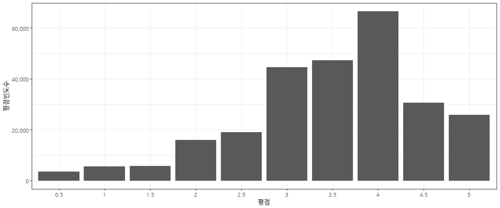

```r
# 3. 탐색적 데이터 분석 -------------------
## 3.1. 평점 전체적 분포 ------------------
rating_df %>% dplyr::count(rating) %>%
    ggplot(data=., aes(x=as.factor(rating), y=n)) +
    geom_bar(stat="identity") +
    theme_bw(base_family = "NanumGothic") +
    labs(x="평점", y="평점빈도수") +
    scale_y_continuous(labels = scales::comma)
```

### 1.2. 가장 평점이 많이 붙은 영화

가장 평점이 많이 붙은 영화 30개를 뽑아낸다. 만약 안 본 영화가 있다면 이번 기회를 통해 꼭 관람하자.

```r
## 3.2. 가장 평점이 많이 붙은 영화 ------------------
rating_df %>% dplyr::count(movieId, sort=TRUE) %>%
    left_join(movie_df) %>%
    top_n(30, n) %>%
    DT::datatable()
```

|  | movieId | n | title | genres |
| --- | --- | --- | --- | --- |
| 1 | m2571 | 668 | Matrix, The (1999) | Action\|Sci-Fi\|Thriller |
| 2 | m4993 | 628 | Lord of the Rings: The Fellowship of the Ring, The (2001) | Adventure\|Fantasy |
| 3 | m356 | 621 | Forrest Gump (1994) | Comedy\|Drama\|Romance\|War |
| 4 | m296 | 613 | Pulp Fiction (1994) | Comedy\|Crime\|Drama\|Thriller |
| 5 | m5952 | 597 | Lord of the Rings: The Two Towers, The (2002) | Adventure\|Fantasy |
| 6 | m2959 | 588 | Fight Club (1999) | Action\|Crime\|Drama\|Thriller |
| 7 | m7153 | 577 | Lord of the Rings: The Return of the King, The (2003) | Action\|Adventure\|Drama\|Fantasy |
| 8 | m318 | 564 | Shawshank Redemption, The (1994) | Crime\|Drama |
| 9 | m260 | 535 | Star Wars: Episode IV - A New Hope (1977) | Action\|Adventure\|Sci-Fi |
| 10 | m593 | 533 | Silence of the Lambs, The (1991) | Crime\|Horror\|Thriller |

[output cut: 20 more lines]

### 1.3. 상위 30개 영화 중 평점이 높은 영화는?

상위 30개 영화를 뽑았는데 과연 어떤 순서로 보는 것이 좋을까? 아마도 평점이 높은 순으로 영화를 보는 것이 좋을 듯 싶다.

```r
## 3.2. 상위 30개 영화 중 평점이 높은 순 ------------
movie_top30_df <- rating_df %>% dplyr::count(movieId, sort=TRUE) %>%
    left_join(movie_df) %>%
    top_n(30, n)

rating_df %>% group_by(movieId) %>%
    summarise(rating_avg = mean(rating)) %>%
    right_join(movie_top30_df) %>%
    arrange(desc(rating_avg)) %>%
    DT::datatable()
```

|  | movieId | rating_avg | n | title | genres |
| --- | --- | --- | --- | --- | --- |
| 1 | m318 | 4.36436170212766 | 564 | Shawshank Redemption, The (1994) | Crime\|Drama |
| 2 | m2959 | 4.25850340136054 | 588 | Fight Club (1999) | Action\|Crime\|Drama\|Thriller |
| 3 | m296 | 4.21778140293638 | 613 | Pulp Fiction (1994) | Comedy\|Crime\|Drama\|Thriller |
| 4 | m2571 | 4.19535928143713 | 668 | Matrix, The (1999) | Action\|Sci-Fi\|Thriller |
| 5 | m4226 | 4.19461697722567 | 483 | Memento (2000) | Mystery\|Thriller |
| 6 | m1196 | 4.10196078431373 | 510 | Star Wars: Episode V - The Empire Strikes Back (1980) | Action\|Adventure\|Sci-Fi |
| 7 | m4993 | 4.09156050955414 | 628 | Lord of the Rings: The Fellowship of the Ring, The (2001) | Adventure\|Fantasy |
| 8 | m260 | 4.08411214953271 | 535 | Star Wars: Episode IV - A New Hope (1977) | Action\|Adventure\|Sci-Fi |
| 9 | m7361 | 4.07473684210526 | 475 | Eternal Sunshine of the Spotless Mind (2004) | Drama\|Romance\|Sci-Fi |
| 10 | m2858 | 4.07073643410853 | 516 | American Beauty (1999) | Comedy\|Drama |

[output cut: 20 more lines]

## 2. 추천시스템 개발을 위한 데이터 전처리

```r
# 4. 데이터 전처리 -------------------
## 4.1. 데이터 크기 비교
rating_rrm <- rating_rrm[rowCounts(rating_rrm) > 100,
                         colCounts(rating_rrm) > 200]

# 데이터 크기 비교
print(object.size(rating_mat), units = "auto")
```

```
16.7 Mb
```

```r
print(object.size(rating_rrm), units = "auto")
```

```
1.1 Mb
```

### 2.1. 데이터 정규화

상위 10%만 뽑아서 `image` 함수로 시각화를 하고 `normalize` 함수를 통해 정규화를 통해 시각적으로 특정한 패턴을 발견할 수 있는지 살펴본다.

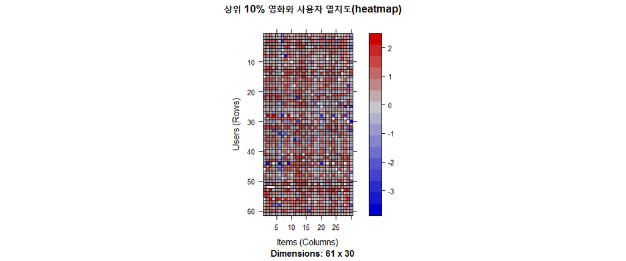

```r
# 5. 상위 유저 분석 -------------------
# 상위 10 %만 탐색적 분석
min_movies <- quantile(rowCounts(rating_rrm), 0.90)
min_users <- quantile(colCounts(rating_rrm), 0.90)

# 정규화
rating_rrm_norm <- normalize(rating_rrm)

# 시각화
image(rating_rrm_norm[rowCounts(rating_rrm_norm) > min_movies,
                      colCounts(rating_rrm_norm) > min_users], main = "상위 10% 영화와 사용자 열지도(heatmap)")
```

## 3. 영화 무비렌즈 추천모형 개발

### 3.1. RMSE 기준 영화 추천

RANDOM 모형이 예측모형 평가를 위한 기본이 되고 이를 바탕으로 `POPULAR`, `IBCF`, `UBCF`, `SVD` 추천 모형을 개발하고 나서, “RMSE”, “MSE”, “MAE” 3가지 측도를 바탕으로 가장 오차가 작은 모형을 선택한다.

```r
# 6. 추천모형 -------------------------
## 6.1. 모형평가 설정
rating_eval_scheme <- evaluationScheme(rating_rrm, method="cross-validation",
                                       k=3, given=3, goodRating=4)

## 6.2. 다수 모형 비교 평가
rcmm_algorithms <- list(
    RANDOM = list(name = "RANDOM", param = NULL),
    POPULAR = list(name = "POPULAR", param = NULL),
    IBCF = list(name = "IBCF", param = NULL),
    UBCF = list(name = "UBCF", param = NULL),
    SVD = list(name = "SVD", param = NULL)
)

rcmm_eval <- evaluate(rating_eval_scheme, rcmm_algorithms, type="ratings")
```

```
RANDOM run fold/sample [model time/prediction time]
     1  [0sec/0.1sec]
     2  [0.02sec/0.03sec]
     3  [0sec/0.05sec]
POPULAR run fold/sample [model time/prediction time]
     1  [0.02sec/0.02sec]
     2  [0.05sec/0.01sec]
     3  [0sec/0.19sec]
IBCF run fold/sample [model time/prediction time]
     1  [0.31sec/0.21sec]
     2  [0.46sec/0.04sec]
     3  [0.32sec/0.02sec]
UBCF run fold/sample [model time/prediction time]
     1  [0.01sec/0.25sec]
     2  [0.01sec/0.25sec]
     3  [0.01sec/0.23sec]
SVD run fold/sample [model time/prediction time]
     1  [0.03sec/0.03sec]
     2  [0.36sec/0.03sec]
     3  [0.04sec/0.01sec]
```

```r
rcmm_eval_df <- map_df(avg(rcmm_eval), rbind)
rcmm_eval_df <- t(rcmm_eval_df)
colnames(rcmm_eval_df) <- c("RMSE", "MSE", "MAE")

DT::datatable(rcmm_eval_df)
```

|  | RMSE | MSE | MAE |
| --- | --- | --- | --- |
| RANDOM | 1.26282597275767 | 1.59532322620428 | 0.964470084364075 |
| POPULAR | 0.944081378152458 | 0.891578358847454 | 0.723084445946435 |
| IBCF | 1.2354916722924 | 1.52755062589943 | 0.919273473885303 |
| UBCF | 0.967513300277173 | 0.936279475405222 | 0.745094585319794 |
| SVD | 0.996591527199307 | 0.993390382918886 | 0.766457634880651 |

앞선 추천모형중 “POPULAR” 예측모형이 가장 성능이 좋게 나와 이를 바탕으로 영화를 추천한다. 이를 바탕으로 첫번째 유저에 대해서 영화를 추천한다.

```r
## 6.3. 모형을 통한 추천

rcmm_model <- Recommender(rating_rrm, method = "POPULAR",
                          param=list(normalize = "center", method="Cosine"))
```

```
Available parameter (with default values):
normalize    =  center
aggregationRatings   =  function (x, na.rm = FALSE, dims = 1, ...)  standardGeneric("colMeans")
aggregationPopularity    =  function (x, na.rm = FALSE, dims = 1, ...)  standardGeneric("colSums")
verbose  =  FALSE
```

```r
best_prediction <- predict(rcmm_model, newdata = rating_rrm, n = 3)

recc_matrix <- sapply(best_prediction@items, function(x){
    colnames(rating_rrm)[x]
})

recc_matrix[,1] %>% as_data_frame() %>%
    rename(movieId=value) %>% left_join(movie_df) %>%
    DT::datatable()
```

|  | movieId | title | genres |
| --- | --- | --- | --- |
| 1 | m4973 | Amelie (Fabuleux destin d'Amélie Poulain, Le) (2001) | Comedy\|Romance |
| 2 | m593 | Silence of the Lambs, The (1991) | Crime\|Horror\|Thriller |
| 3 | m7361 | Eternal Sunshine of the Spotless Mind (2004) | Drama\|Romance\|Sci-Fi |

### 3.2. 상위 N개 영화 기준

RMSE도 훌륭한 측도지만 결국 추천하는 상위 1, 3, 5, 10개 추천한 영화중에 포함되었는지를 측도로 활용하는 것이 추천시스템 개발에 좀더 현실적일 수 있다. 위와 동일하기 때문에 사용자별 영화 추천은 생략한다.

```r
# 7. 상위 N개 추천 -------------------------
## 7.1. 모형평가 설정
rating_eval_scheme <- evaluationScheme(rating_rrm, method="cross-validation",
                                       k=3, given=10, goodRating=5)

## 7.2. 다수 모형 비교 평가
rcmm_algorithms <- list(
    UBCF_cos = list(name = "UBCF", param = list(method ="cosine")),
    UBCF_cor = list(name = "UBCF", param = list(method ="pearson")),
    RANDOM = list(name = "RANDOM", param = NULL),
    POPULAR = list(name = "POPULAR", param = NULL),
    SVD = list(name = "SVD", param = NULL)
)

rcmm_topN_eval <- evaluate(rating_eval_scheme, rcmm_algorithms, type="topNList", n=c(1, 3, 5, 10))
```

```
UBCF run fold/sample [model time/prediction time]
     1  [0sec/0.34sec]
     2  [0sec/0.37sec]
     3  [0sec/0.33sec]
UBCF run fold/sample [model time/prediction time]
     1  [0.01sec/0.33sec]
     2  [0sec/0.31sec]
     3  [0.01sec/0.31sec]
RANDOM run fold/sample [model time/prediction time]
     1  [0sec/0.11sec]
     2  [0sec/0.09sec]
     3  [0sec/0.09sec]
POPULAR run fold/sample [model time/prediction time]
     1  [0.02sec/0.31sec]
     2  [0sec/0.31sec]
     3  [0sec/0.33sec]
SVD run fold/sample [model time/prediction time]
     1  [0.03sec/0.09sec]
     2  [0.02sec/0.09sec]
     3  [0.03sec/0.1sec]
```

```r
avg(rcmm_topN_eval)
```

```
$UBCF_cos
         TP        FP       FN       TN precision     recall        TPR
1  0.273752 0.7246377 17.70209 289.2995 0.2741898 0.01858732 0.01858732
3  0.805153 2.1900161 17.17069 287.8341 0.2688012 0.05858682 0.05858682
5  1.202899 3.7890499 16.77295 286.2351 0.2409659 0.08947205 0.08947205
10 2.162641 7.8212560 15.81320 282.2029 0.2166049 0.15588011 0.15588011
           FPR
1  0.002469323
3  0.007465528
5  0.012936170
10 0.026727307

$UBCF_cor
          TP        FP       FN       TN precision     recall        TPR
1  0.2673108 0.7310789 17.70853 289.2931 0.2677173 0.02353220 0.02353220
3  0.6876006 2.3075684 17.28824 287.7166 0.2295285 0.05013479 0.05013479
5  1.0821256 3.9098229 16.89372 286.1143 0.2167456 0.07845631 0.07845631
10 1.8824477 8.1014493 16.09340 281.9227 0.1885348 0.12945848 0.12945848
           FPR
1  0.002493965
3  0.007876633
5  0.013361794
10 0.027734637

$RANDOM
          TP        FP       FN       TN  precision      recall
1  0.0821256 0.9178744 17.89372 289.1063 0.08212560 0.003478365
3  0.2190016 2.7809984 17.75684 287.2432 0.07300054 0.009373720
5  0.3574879 4.6425121 17.61836 285.3816 0.07149758 0.017047464
10 0.6409018 9.3590982 17.33494 280.6651 0.06409018 0.032435325
           TPR         FPR
1  0.003478365 0.003155617
3  0.009373720 0.009573355
5  0.017047464 0.015974041
10 0.032435325 0.032240001

$POPULAR
          TP        FP       FN       TN precision     recall        TPR
1  0.2898551 0.7101449 17.68599 289.3140 0.2898551 0.02572048 0.02572048
3  0.8454106 2.1545894 17.13043 287.8696 0.2818035 0.06721057 0.06721057
5  1.3365539 3.6634461 16.63929 286.3607 0.2673108 0.10071493 0.10071493
10 2.3558776 7.6441224 15.61997 282.3800 0.2355878 0.17371748 0.17371748
          FPR
1  0.00241720
3  0.00732778
5  0.01247075
10 0.02608547

$SVD
          TP        FP       FN       TN precision     recall        TPR
1  0.2431562 0.7568438 17.73269 289.2673 0.2431562 0.01860029 0.01860029
3  0.6038647 2.3961353 17.37198 287.6280 0.2012882 0.04427703 0.04427703
5  0.8953301 4.1046699 17.08052 285.9195 0.1790660 0.06696335 0.06696335
10 1.5314010 8.4685990 16.44444 281.5556 0.1531401 0.10589833 0.10589833
           FPR
1  0.002582907
3  0.008205864
5  0.014068077
10 0.029029477
```

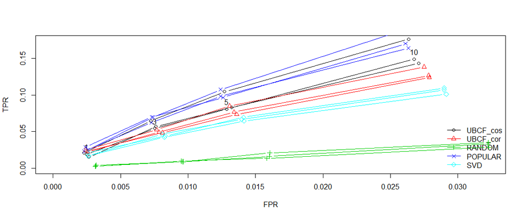

```r
plot(rcmm_topN_eval, annotate = TRUE, avg=FALSE)
```

[^1]: [Recommender Systems: Evaluation](http://michael.hahsler.net/other_courses/ICMA_Recommendation_Tools/code/evaluation.html)